# Name: Tessa Nejla Ayvazoglu

# StudentID: 8686601

# Please submit the notebook and HTML version of your notebook to EConestoga Dropbox

# **Question 1 - Pandas** (12 marks)

- Using RegularSeasonCompactResults.csv
- and Teams.csv

```python
# Using RegularSeasonCompactResults.csv
# 1- Create a filter to show if there are any draw matches
# 2- Apply the filter to the dataframe
# 3- SHOW the dataframe length or count (4 marks)
## TODO: Your code should be here
import pandas as pd

# Load the DataFrame from the CSV file
data = pd.read_csv("C:\\Users\\Admin\\Desktop\\C_AIML\\MLF\\week4\\Data\\RegularSeasonCompactResults.csv")

# Create a filter for draw matches
draw_filter = data['Wscore'] == data['Lscore']

# Check if there are any draw matches
if draw_filter.any():
    print("There are draw matches in the dataset.")
    draw_matches_df = data[draw_filter]
    print("Number of draw matches:", len(draw_matches_df))
    print(draw_matches_df.head())
else:
    print("There are no draw matches in the dataset.")

draw_matches_df.head()
```

[output not shown]

|  | Season | Daynum | Wteam | Wscore | Lteam | Lscore | Wloc | Numot |
| --- | --- | --- | --- | --- | --- | --- | --- | --- |

```python
# Using RegularSeasonCompactResults.csv
# 1- Create a filter showing the entries where the winningteamID= 1400- (last two digits of your id)
# 2- Create another filter for the season of 2013
# 3- Apply the filter to the dataframe
# 4- Show the resulted dataframe (4 marks)
# (Example: IF your id is 8000021, the winning team id = 1400-21= 1389)
# TODO: Your code should be here
import pandas as pd

# Load the DataFrame from the CSV file
data = pd.read_csv("C:\\Users\\Admin\\Desktop\\C_AIML\\MLF\\week4\\Data\\RegularSeasonCompactResults.csv")

# Define your ID and calculate the winning team ID
my_id = 8686601
# Extract the last two digits of your ID
last_two_digits = my_id % 100
winning_team_id = 1400 - last_two_digits

# 1- Create a filter for the winning team ID
winning_team_filter = data['Wteam'] == winning_team_id

# 2- Create a filter for the season of 2013
season_2013_filter = data['Season'] == 2013

# 3- Apply the filters to the DataFrame
filtered_df = data[winning_team_filter & season_2013_filter]

# 4- Show the resulted DataFrame
print("Resulted DataFrame:")
print(filtered_df.head())
```

```
Resulted DataFrame:
        Season  Daynum  Wteam  Wscore  Lteam  Lscore Wloc  Numot
124196    2013      10   1399      71   1157      69    H      0
124311    2013      12   1399      65   1190      62    A      0
125122    2013      31   1399      74   1453      68    H      0
125373    2013      40   1399      69   1454      58    A      0
126333    2013      66   1399      77   1183      73    A      0
```

```python
# Using RegularSeasonCompactResults.csv & Teams.csv
# 1- Load and merge both dataframes
# 2- Where the merge is on WinningTeamId (RegularSeasonCompactResults) and TeamId (Teams.csv)
# 3- Name the dataframe: DFCombined
# 4- Show the top 3 rows (4 marks)
# TODO: Your code should be here
import pandas as pd

# Load the RegularSeasonCompactResults.csv and Teams.csv data
results_data = pd.read_csv("C:\\Users\\Admin\\Desktop\\C_AIML\\MLF\\week4\\Data\\RegularSeasonCompactResults.csv")
teams_data = pd.read_csv("C:\\Users\\Admin\\Desktop\\C_AIML\\MLF\\week4\\Data\\Teams.csv")

# Print the columns of the Teams dataframe to check the column names
print("Columns in Teams.csv:", teams_data.columns)

# Merge the dataframes on WinningTeamId and TeamId
DFCombined = pd.merge(results_data, teams_data, left_on='Wteam', right_on='Team_Id', how='inner')

# Show the top 3 rows of the resulting dataframe
print("Top 3 rows of DFCombined:")
print(DFCombined.head(3))
```

```
Columns in Teams.csv: Index(['Team_Id', 'Team_Name'], dtype='object')
Top 3 rows of DFCombined:
   Season  Daynum  Wteam  Wscore  Lteam  Lscore Wloc  Numot  Team_Id Team_Name
0    1985      20   1228      81   1328      64    N      0     1228  Illinois
1    1985      25   1228      64   1226      44    N      0     1228  Illinois
2    1985      27   1228      75   1332      72    N      3     1228  Illinois
```

# **Question 2 - Visualizations**

## **Part I**

Using the following dataset: https://raw.githubusercontent.com/mwaskom/seaborn-data/master/penguins.csv choose the most convenient graph to show the following, each question in **one** graph, using the library of your choice: (18 Marks)

**1. The relationship between the penguin's bill length and bill depth for each species.** (5 marks)

Scatter Plot:

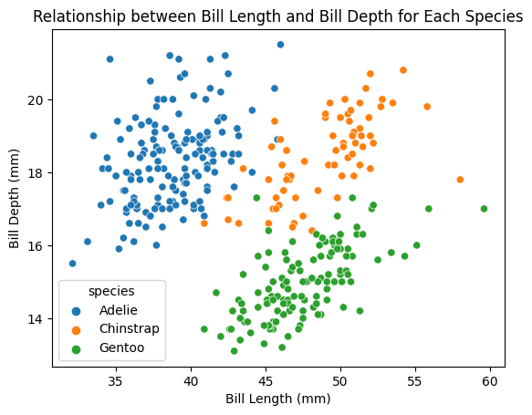

```python
## TODO: Check your attributes, make a graph using Matplotlib or Seaborn to show the relationship needed
import pandas as pd
import seaborn as sns
import matplotlib.pyplot as plt

# Load the dataset
penguins = pd.read_csv("C:\\Users\\Admin\\Desktop\\C_AIML\\MLF\\week4\\Data\\penguins.csv")  # Replace with the actual path

# Create a scatter plot using Seaborn
sns.scatterplot(x='bill_length_mm', y='bill_depth_mm', hue='species', data=penguins)

# Set labels and title
plt.xlabel('Bill Length (mm)')
plt.ylabel('Bill Depth (mm)')
plt.title('Relationship between Bill Length and Bill Depth for Each Species')

# Show the plot
plt.show()
```

Pair Plot:

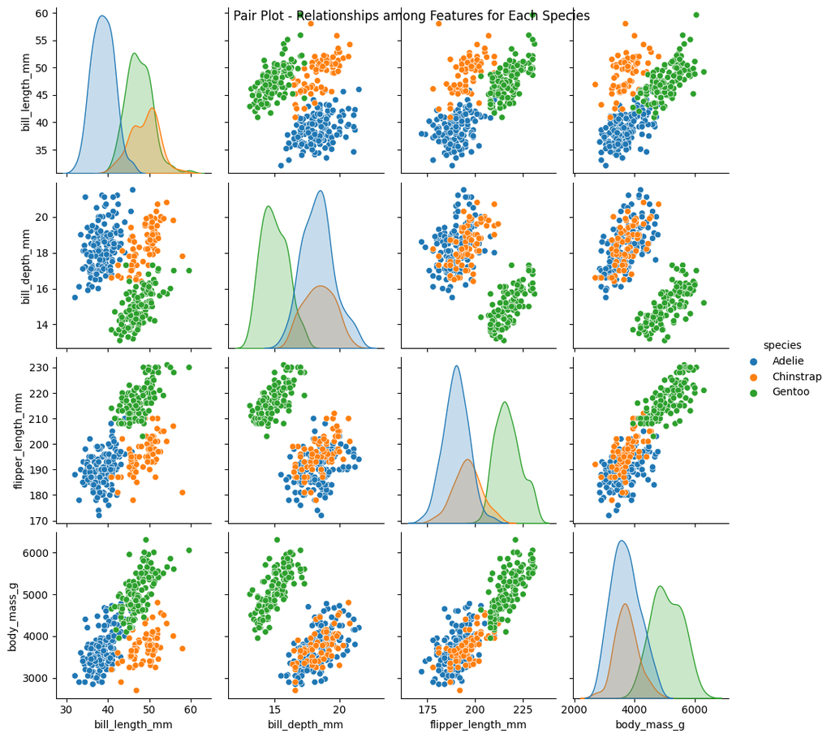

```python
import pandas as pd
import seaborn as sns
import matplotlib.pyplot as plt

# Load the dataset
penguins = pd.read_csv("C:\\Users\\Admin\\Desktop\\C_AIML\\MLF\\week4\\Data\\penguins.csv")  # Replace with the actual path

# Create a pair plot using Seaborn
sns.pairplot(penguins, hue='species')

# Set title
plt.suptitle('Pair Plot - Relationships among Features for Each Species')

# Show the plot
plt.show()
```

Box Plot:

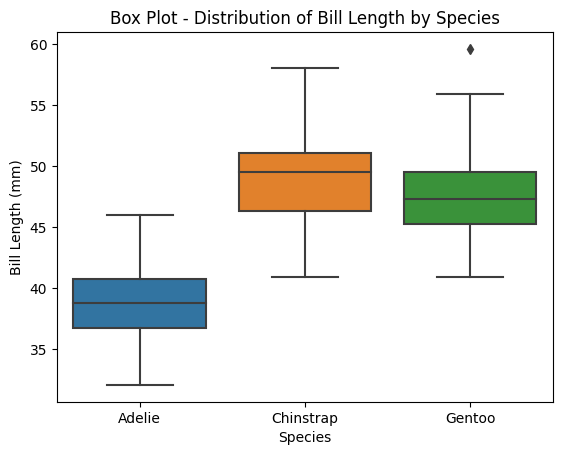

```python
import pandas as pd
import seaborn as sns
import matplotlib.pyplot as plt

# Load the dataset
penguins = pd.read_csv("C:\\Users\\Admin\\Desktop\\C_AIML\\MLF\\week4\\Data\\penguins.csv")  # Replace with the actual path

# Create a box plot using Seaborn
sns.boxplot(x='species', y='bill_length_mm', data=penguins)

# Set labels and title
plt.xlabel('Species')
plt.ylabel('Bill Length (mm)')
plt.title('Box Plot - Distribution of Bill Length by Species')
```

**What do you observe from the graph?** (2 marks)

- When comparing different penguin species, we can observe that bill length and depth have a similar relationship (shown by similar slopes) but each species has a different range of these variables (as indicated by the different colors). Adelie penguins have relatively smaller bill length but larger bill depth, whereas Gentoo penguins have the opposite pattern. Chinstrap penguins have big bill lengths and large bill depths as well.

**Why did you choose this type of graph?** (2 marks)

Your answer here:

- We can already see some species groupings between bill length and bill depth. We chose this graph because, when plotting, it will be important to differentiate species.

**2. Suitable graph of the mean BMI (BMI not body_mass weight_in_kg/height(m2)) of female and male penguins. (Assume the height is the flipper length)** (5 marks)

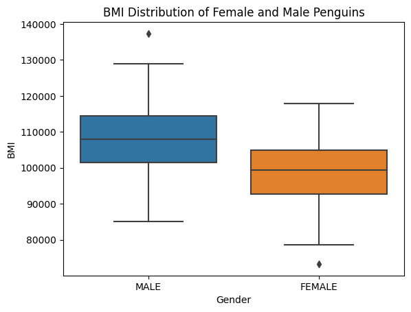

```python
#Your answer here
import pandas as pd
import seaborn as sns
import matplotlib.pyplot as plt

# Load the dataset
penguins = pd.read_csv("C:\\Users\\Admin\\Desktop\\C_AIML\\MLF\\week4\\Data\\penguins.csv")  # Replace with the actual path

# Calculate BMI (BMI = weight_in_kg / (height_in_m)^2)
penguins['BMI'] = penguins['body_mass_g'] / ((penguins['flipper_length_mm'] / 1000) ** 2)

# Create a box plot using Seaborn
sns.boxplot(x='sex', y='BMI', data=penguins)

# Set labels and title
plt.xlabel('Gender')
plt.ylabel('BMI')
plt.title('BMI Distribution of Female and Male Penguins')

# Show the plot
plt.show()
```

Your answer here:

For Male Penguins:

Range: The range of BMI for male penguins is broader (130,000 - 85,000 = 45,000) compared to female penguins (120,000 - 80,000 = 40,000). Central Tendency: The mean and median values are close for both male and female penguins, indicating a relatively symmetric distribution. Outliers: The box plot may reveal the presence of outliers beyond the whiskers, which are points beyond 1.5 times the interquartile range (IQR) from the quartiles.

**Why did you choose this type of graph?** (2 marks)

Your answer here:

- Box plots are effective for comparing the distributions of different groups, in this case, male and female penguins. The box plot's structure allows for easy comparison of key statistics between the two groups.While other plot types like bar plots or histograms could also be used, a box plot is particularly well-suited for comparing distributions and identifying outliers in this context.

## **Part II**

You can find the csv file that contains the museum visitors data here: ./CSVs/museum_visitors.csv (8 marks)

Review the data by taking a look at a few of the rows.

```python
# Your solution here
import pandas as pd
import seaborn as sns
import matplotlib.pyplot as plt

# Load the dataset
file_path = "C:\\Users\\Admin\\Desktop\\C_AIML\\MLF\\week4\\Data\\museum_visitors.csv"
df = pd.read_csv(file_path)

df.head()
```

|  | Date | Avila Adobe | Firehouse Museum | Chinese American Museum | America Tropical Interpretive Center |
| --- | --- | --- | --- | --- | --- |
| 0 | 2014-01-01 | 24778 | 4486 | 1581 | 6602 |
| 1 | 2014-02-01 | 18976 | 4172 | 1785 | 5029 |
| 2 | 2014-03-01 | 25231 | 7082 | 3229 | 8129 |
| 3 | 2014-04-01 | 26989 | 6756 | 2129 | 2824 |
| 4 | 2014-05-01 | 36883 | 10858 | 3676 | 10694 |

Convince the museum board

The Firehouse Museum claims they ran an event in 2014 that brought an incredible number of visitors, and that they should get extra budget to run a similar event again. The other museums think these types of events aren't that important, and budgets should be split purely based on recent visitors on an average day.

To show the museum board how the event compared to regular traffic at each museum, create a suitable chart that shows how the number of visitors to each museum evolved over time. (4 marks)

```python
#Your solution here

import pandas as pd
import seaborn as sns
import matplotlib.pyplot as plt

# Set the file path
file_path = "C:\\Users\\Admin\\Desktop\\C_AIML\\MLF\\week4\\Data\\museum_visitors.csv"

# Load the dataset
df = pd.read_csv(file_path)

# Find the column containing the date (assuming it's the first date-like column)
date_column = next((col for col in df.columns if pd.api.types.is_datetime64_any_dtype(df[col])), None)

# Check if a date column is found
if date_column:
    # Convert the date column to datetime format
    df[date_column] = pd.to_datetime(df[date_column])

    # Melt the dataframe to have a 'Location' and 'Visitors' column
    melted_df = pd.melt(df, id_vars=[date_column], var_name='Location', value_name='Visitors')

    # Calculate the average visitors per day for each location
    avg_visitors = melted_df.groupby('Location')['Visitors'].mean().reset_index()

    # Filter data for the Firehouse Museum in 2014
    firehouse_data = melted_df[melted_df['Location'] == 'Firehouse Museum']
    firehouse_data = firehouse_data[firehouse_data[date_column].dt.year == 2014]

    # Create a line plot for museum visitors over time
    plt.figure(figsize=(14, 8))
    sns.lineplot(x=date_column, y='Visitors', hue='Location', data=avg_visitors, label='Average Visitors')
    sns.lineplot(x=date_column, y='Visitors', data=firehouse_data, label='Firehouse Museum Event', linewidth=2)

    # Set labels and title
    plt.xlabel('Date')
    plt.ylabel('Number of Visitors')
    plt.title('Comparison of Firehouse Museum Event to Average Visitors Over Time')

    # Rotate x-axis labels for better readability
    plt.xticks(rotation=45)

    # Show the plot
    plt.legend()
    plt.show()

else:
    print("No date column found in the dataset.")
```

[output not shown]

[output not shown]

```
No date column found in the dataset.
```

## **PART III**

Using the file in ./CSVs/gas_prices.csv  
Use a suitable plot/graph that will show the relationship between the gas price for each country (vs others) over all years. (8 marks)

First, review the data by taking a look at a few of the rows.

```python
# Your solution here
import pandas as pd
import seaborn as sns
import matplotlib.pyplot as plt

# Load the dataset
file_path = "C:\\Users\\Admin\\Desktop\\C_AIML\\MLF\\week4\\Data\\gas_prices.csv"
df = pd.read_csv(file_path)

df.head()
```

|  | Year | Australia | Canada | France | Germany | Italy | Japan | Mexico | South Korea | UK | USA |
| --- | --- | --- | --- | --- | --- | --- | --- | --- | --- | --- | --- |
| 0 | 1990 | NaN | 1.87 | 3.63 | 2.65 | 4.59 | 3.16 | 1.00 | 2.05 | 2.82 | 1.16 |
| 1 | 1991 | 1.96 | 1.92 | 3.45 | 2.90 | 4.50 | 3.46 | 1.30 | 2.49 | 3.01 | 1.14 |
| 2 | 1992 | 1.89 | 1.73 | 3.56 | 3.27 | 4.53 | 3.58 | 1.50 | 2.65 | 3.06 | 1.13 |
| 3 | 1993 | 1.73 | 1.57 | 3.41 | 3.07 | 3.68 | 4.16 | 1.56 | 2.88 | 2.84 | 1.11 |
| 4 | 1994 | 1.84 | 1.45 | 3.59 | 3.52 | 3.70 | 4.36 | 1.48 | 2.87 | 2.99 | 1.11 |

Then Plot using the most suitable plot on your opinion (5 marks)

```
   Year  Australia  Canada  France  Germany  Italy  Japan  Mexico
0  1990        NaN    1.87    3.63     2.65   4.59   3.16    1.00  \
1  1991       1.96    1.92    3.45     2.90   4.50   3.46    1.30
2  1992       1.89    1.73    3.56     3.27   4.53   3.58    1.50
3  1993       1.73    1.57    3.41     3.07   3.68   4.16    1.56
4  1994       1.84    1.45    3.59     3.52   3.70   4.36    1.48

   South Korea    UK   USA
0         2.05  2.82  1.16
1         2.49  3.01  1.14
2         2.65  3.06  1.13
3         2.88  2.84  1.11
4         2.87  2.99  1.11
```

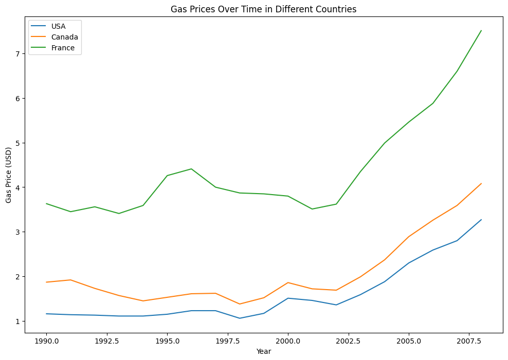

```python
## Your solution here
import pandas as pd
import seaborn as sns
import matplotlib.pyplot as plt

# Load the dataset
file_path = "C:\\Users\\Admin\\Desktop\\C_AIML\\MLF\\week4\\Data\\gas_prices.csv"
df = pd.read_csv(file_path)

# Display the first few rows of the dataset to understand its structure
print(df.head())

# Assuming the dataset contains columns like 'Year', 'USA', 'Canada', 'France', etc.
# Replace these column names with the actual columns in your dataset
# Plotting gas prices over time for multiple countries
plt.figure(figsize=(12, 8))
sns.lineplot(x='Year', y='USA', data=df, label='USA')
sns.lineplot(x='Year', y='Canada', data=df, label='Canada')
sns.lineplot(x='Year', y='France', data=df, label='France')

# Set labels and title
plt.xlabel('Year')
plt.ylabel('Gas Price (USD)')
plt.title('Gas Prices Over Time in Different Countries')

# Show the legend
plt.legend()

# Show the plot
plt.show()
```

Is there anything interesting observed from the plot/graph? (1 mark)

Your answer here

- such as the increase in gas prices for all three countries after 2002, the relative affordability of gas in the USA compared to other countries, and the specific years where each country experienced significant changes in gas prices, provide valuable information. These trends can be crucial for understanding the economic dynamics and factors influencing gas prices in different regions.

Why did you choose this type of graph? (2 marks)

You answer here

- Matplotlib is a commonly used plotting library, and plt provides an easy and straightforward way to create various types of plots and charts. It is often preferred for its ease of use, particularly for simple visualizations, so that is why I used it.